## Background

Using devices such as Jawbone Up, Nike FuelBand, and Fitbit it is now possible to collect a large amount of data about personal activity relatively inexpensively. These type of devices are part of the quantified self movement: a group of enthusiasts who take measurements about themselves regularly to improve their health, to find patterns in their behavior, or because they are tech geeks. One thing that people regularly do is quantify how much of a particular activity they do, but they rarely quantify how well they do it.

## Introduction

This project uses data from accelerometers on the belt, forearm, arm, and dumbell of 6 participants. They were asked to perform barbell lifts correctly and incorrectly in 5 different ways. They were asked to perform one set of 10 repetitions of the Unilateral Dumbbell Biceps Curl in five different fashions: “exactly according to the specification (Class A), throwing the elbows to the front (Class B), lifting the dumbbell only halfway (Class C) , lowering the dumbbell only halfway (Class D) and throwing the hips to the front” (Class E).

1. The goal of our project is to predict the manner in which they did the exercise.
2. The “classe” variable in the training set is the outcome variable.
3. There are variables to predict the “classe” with.

## Libraries

```r
library (caret)
```

```r
library (rpart)
library (ggplot2)
library (rpart.plot)
library (rattle)
library (randomForest)
library (corrplot)
library (partykit)
```

## Data Exploration

```r
trainingdata<-read.csv("http://d396qusza40orc.cloudfront.net/predmachlearn/pml-training.csv" , header=TRUE)
testcases<-read.csv("http://d396qusza40orc.cloudfront.net/predmachlearn/pml-testing.csv", header=TRUE)
#Checking the Dimension of the Data files.
dim (trainingdata)
```

```
## [1] 19622   160
```

```r
dim(testcases)
```

```
## [1]  20 160
```

Looking at the dimensions, we see that there are total of 19,622 observations in the trainingdata and 20 in the testcases. There are total of 160 different variables, and the variable “classe” is going to be the outcome variable. Before that, let’s reduce the number of variables that have near zero values (NZV)in both trainingdata, and testcases.

```r
NZV<-nearZeroVar (trainingdata)
trainingdata<-trainingdata[, - NZV]
testcases<-testcases[, - NZV]
head(testcases)
```

[output not shown]

[output cut: 139 more lines]

```r
str(testcases)
```

```
## 'data.frame':    20 obs. of  100 variables:
##  $ X                       : int  1 2 3 4 5 6 7 8 9 10 ...
##  $ user_name               : chr  "pedro" "jeremy" "jeremy" "adelmo" ...
##  $ raw_timestamp_part_1    : int  1323095002 1322673067 1322673075 1322832789 1322489635 1322673149 1322673128 1322673076 1323084240 1322837822 ...
##  $ raw_timestamp_part_2    : int  868349 778725 342967 560311 814776 510661 766645 54671 916313 384285 ...
##  $ cvtd_timestamp          : chr  "05/12/2011 14:23" "30/11/2011 17:11" "30/11/2011 17:11" "02/12/2011 13:33" ...
##  $ num_window              : int  74 431 439 194 235 504 485 440 323 664 ...
##  $ roll_belt               : num  123 1.02 0.87 125 1.35 -5.92 1.2 0.43 0.93 114 ...
##  $ pitch_belt              : num  27 4.87 1.82 -41.6 3.33 1.59 4.44 4.15 6.72 22.4 ...
##  $ yaw_belt                : num  -4.75 -88.9 -88.5 162 -88.6 -87.7 -87.3 -88.5 -93.7 -13.1 ...
##  $ total_accel_belt        : int  20 4 5 17 3 4 4 4 4 18 ...
##  $ max_roll_belt           : logi  NA NA NA NA NA NA ...
##  $ max_picth_belt          : logi  NA NA NA NA NA NA ...
##  $ min_roll_belt           : logi  NA NA NA NA NA NA ...
##  $ min_pitch_belt          : logi  NA NA NA NA NA NA ...
```

[output cut: 86 more lines]

Variables 1-5 appear related to ID variables. These will be removed with the following code (along with NA values):

```r
trainingdata<-trainingdata[, - (1 :5)]
testcases<-testcases[, - (1 : 5)]

NAs<- sapply (trainingdata, function (x) mean (is.na (x))) >0.95
trainingdata<-trainingdata[, NAs==FALSE]
testcases<-testcases[, NAs==FALSE]
```

We have reduced the number of variables in this model from 160 to 54.

A correlation will be conducted here to determine if there are any more variables that can be dropped.

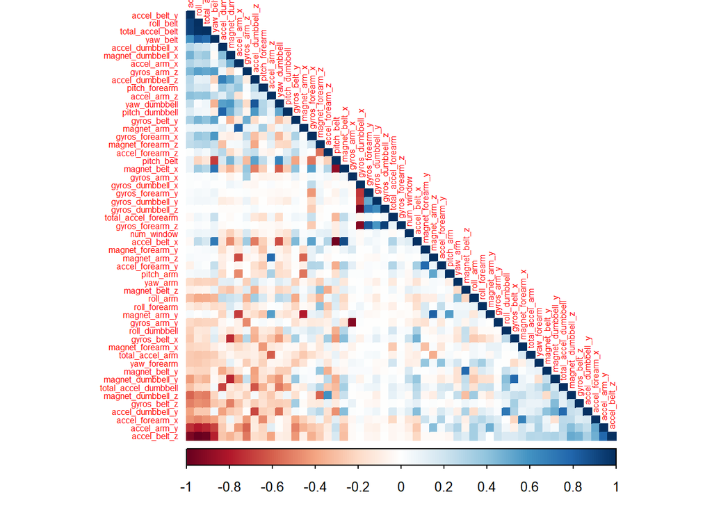

```r
Matrixcor<-cor (trainingdata[, - 54])
corrplot (Matrixcor, type= "lower" , order= "FPC" , method= "color" , tl.cex=0.5)
```

# Training, Testing, & Validation

The following code trains the data and tests them as well. We find a total of 11,776 observations in the training set and 7,846 in the test set.

```r
TrainD<-createDataPartition (trainingdata$classe, p=0.6 , list=FALSE)
trainingset<-trainingdata[TrainD, ]
testset<-trainingdata[- TrainD, ]
dim (trainingset)
```

```
## [1] 11776    54
```

```r
dim(testset)
```

```
## [1] 7846   54
```

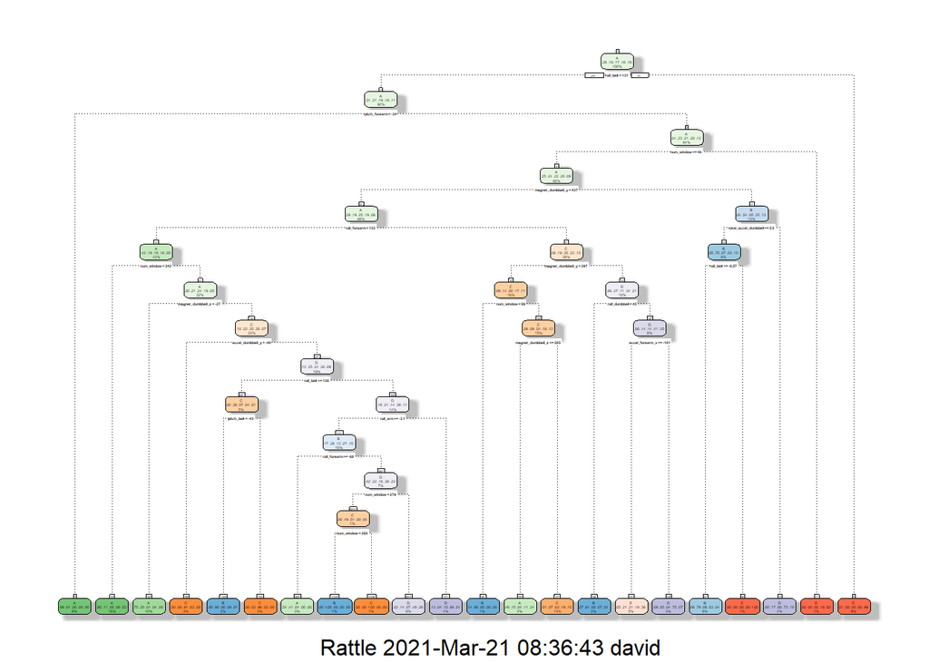

```r
set.seed(123)
modell<-rpart(classe~., data=trainingset, method= "class" )
fancyRpartPlot(modell)
```

```r
valid <- predict(modell, newdata = testcases)
valid
```

```
##             A           B           C          D           E
## 1  0.13571429 0.864285714 0.000000000 0.00000000 0.000000000
## 2  0.74911972 0.195422535 0.014084507 0.03697183 0.004401408
## 3  0.04545455 0.209090909 0.205454545 0.17636364 0.363636364
## 4  0.80311731 0.106644791 0.001640689 0.05824446 0.030352748
## 5  0.80311731 0.106644791 0.001640689 0.05824446 0.030352748
## 6  0.01150982 0.069735951 0.628300609 0.19228165 0.098171970
## 7  0.09164420 0.045822102 0.040431267 0.74932615 0.072776280
## 8  0.02307692 0.144615385 0.070769231 0.48307692 0.278461538
## 9  0.99374348 0.006256517 0.000000000 0.00000000 0.000000000
## 10 0.74911972 0.195422535 0.014084507 0.03697183 0.004401408
## 11 0.01150982 0.069735951 0.628300609 0.19228165 0.098171970
## 12 0.01150982 0.069735951 0.628300609 0.19228165 0.098171970
## 13 0.45620438 0.153284672 0.040145985 0.10948905 0.240875912
## 14 0.99374348 0.006256517 0.000000000 0.00000000 0.000000000
## 15 0.04545455 0.209090909 0.205454545 0.17636364 0.363636364
## 16 0.02307692 0.144615385 0.070769231 0.48307692 0.278461538
## 17 0.80311731 0.106644791 0.001640689 0.05824446 0.030352748
## 18 0.74911972 0.195422535 0.014084507 0.03697183 0.004401408
## 19 0.80311731 0.106644791 0.001640689 0.05824446 0.030352748
## 20 0.06787330 0.814479638 0.004524887 0.07239819 0.040723982
```